# Examining PacBio data with pbbamr

## Examining Individual Alignments

Given an index file, we may want to drill down and examine the individul alignments. `pbbamr` allows you to do this if you have an indexed fasta file of the reference available. The function `loadAlnsFromIndex` will take a list of file offsets (from the pbi index file) and return each BAM record specified by a file offset as a data frame with rows corresponding to alignment positions and columns as read or reference bases.

```r
# Get the name of the sample indexed FASTA file
fastaname = system.file("extdata", "lambdaNEB.fa", package="pbbamr")
# let's just grab and plot one alignment.
allAlns = loadAlnsFromIndex(ind, fastaname, 1)
# The alignments are returned as a list of data frames
# in this case let's just look at the first
aln = allAlns[[1]]
head(aln[1:6,])
```

```
##   read ref
## 1    G   G
## 2    G   G
## 3    G   G
## 4    C   C
## 5    G   G
## 6    G   G
```

Each alignment (or BAM record) is returned as a data frame element of a list. With this, one could combine all of these into one super alignment to gain statistics. For example, let’s validate that the number of insertions in the alignments matches the pbi file.

```r
# Get all the alignments for all records in the index
allAlns = loadAlnsFromIndex(ind, fastaname)
# let's combine the individual alignments into one big data frame
alns = do.call(rbind, allAlns)
# Now count the number of insertions
insert_cnt = sum(alns$ref == "-")
# Do they match the pbi file?
insert_cnt == sum(ind$inserts)
## [1] TRUE
```

More usefully though, one may want to perform some operation over a set of alignments to gather some summary statistics from them. For example, let’s write a cheesy function to figure out for single deletion events which basepair was deleted and which basepair followed that deletion.

```r
# First let's write a function to find single deletion events, and report
# the deleted base and following base.
findSingleDeletions <- function(aln) {
  # Where are the deletions of size 1?
  # First we will convert it to run length encoding (gap = 5)
  rls = rle(as.integer(aln$read))
  # Now find out what has a deletion of size 1
  del_size1 = which(rls$values == 5 & rls$lengths == 1)
  # and convert back from run length to standard coordinates
  org_positions = cumsum(rls$lengths)
  single_del_locs = org_positions[del_size1]
  # Presumably the alignment should not end with
  # a deletion, but let's be sure
  single_del_locs = single_del_locs[single_del_locs < nrow(aln)]
  # And now let's grab the deleted base and the one after
  data.frame(AfterDeletion = aln$ref[single_del_locs + 1],
             Deleted = aln$ref[single_del_locs])
}
# Apply our function to investigate deletions to all alignments
deletions = lapply(allAlns, findSingleDeletions)
# Combine the results
dels = do.call(rbind, deletions)
# And examine the table
knitr::kable(table(dels$AfterDeletion, dels$Deleted))
```

|  | A | C | G | T | - | N |
| --- | --- | --- | --- | --- | --- | --- |
| A | 126 | 38 | 53 | 18 | 0 | 0 |
| C | 29 | 222 | 86 | 42 | 0 | 0 |
| G | 42 | 29 | 330 | 59 | 0 | 0 |
| T | 45 | 26 | 75 | 106 | 0 | 0 |
| - | 0 | 0 | 0 | 0 | 0 | 0 |
| N | 0 | 0 | 0 | 0 | 0 | 0 |

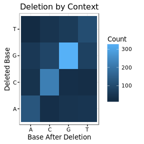

```r
# Tables can also be visualized as heatmaps
dels$Count = 1
agg = aggregate(Count ~ AfterDeletion + Deleted, dels, length )
ggplot(agg, aes(x=AfterDeletion, y=Deleted, fill=Count)) + geom_tile() +
  theme_bw(base_size=10)  +
  labs(title="Deletion by Context",
       x="Base After Deletion", y="Deleted Base")
```

## More Advanced Alignment Metrics

pbbamr also enables you to see valuable metrics like SNR, pkMid, the start frame and the pulse width if they are available in the alignment file (as they are in internal mode BAMS).

```r
ifastaname = system.file("extdata", "All4Mer.V2.11.fna", package="pbbamr")
ibamname = system.file("extdata", "internalsample.bam", package="pbbamr")
# Load the index table.
iind = loadPBI(ibamname)
allAlns = loadAlnsFromIndex(iind, ifastaname)
# let's combine the individual alignments into one big data frame
alns = do.call(rbind, allAlns)
knitr::kable(head(alns[1:6,]))
```

| read | ref | ipd | pw | snrA | snrC | snrG | snrT | pkmid | sf |
| --- | --- | --- | --- | --- | --- | --- | --- | --- | --- |
| G | G | 226 | 1 | 6.987833 | 12.82881 | 8.718133 | 12.93477 | 0.0 | 48324 |
| C | C | 28 | 15 | 6.987833 | 12.82881 | 8.718133 | 12.93477 | 111.1 | 48353 |
| A | A | 10 | 5 | 6.987833 | 12.82881 | 8.718133 | 12.93477 | 60.2 | 48378 |
| G | G | 45 | 11 | 6.987833 | 12.82881 | 8.718133 | 12.93477 | 66.6 | 48428 |
| A | A | 20 | 13 | 6.987833 | 12.82881 | 8.718133 | 12.93477 | 60.0 | 48459 |
| C | C | 12 | 41 | 6.987833 | 12.82881 | 8.718133 | 12.93477 | 109.1 | 48484 |

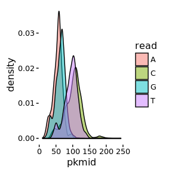

```r
ggplot(alns[alns$pkmid!=0,], aes(x=pkmid, fill=read)) + geom_density(alpha=.5) + theme_classic()
```

## Getting header information

You can obtain most of the information available in the header simply by calling the loadHeader function.

```r
header = loadHeader(ibamname)
# Print out some of the items available in the list
header$version
```

[1] “1.5”

```r
knitr::kable(header$readgroups)
```

| movie | platform | chemistry | framerate | bindingkit | basecaller |
| --- | --- | --- | --- | --- | --- |
| m54007_160210_232804 | PACBIO |  | 80.000000 | 100-619-300 | 3.0.17.173171 |

```r
knitr::kable(header$sequences)
```

| reference | length |
| --- | --- |
| All4mer.V2.11_circular_72x_l50256 | 48312 |

```r
knitr::kable(header$programs)
```

| name | version | cmdline |
| --- | --- | --- |
| BLASR | 2.0.0 | /pbi/dept/secondary/builds/3.0.3/smrtanalysis/prebuilt/linux/x86-64/libc-2.5/gcc-4.8.4/ubuntu-1404/172135/smrtanalysis_3.0.3.172135.installdir/private/pacbio/blasr/binwrap/../bin/blasr /home/UNIXHOME/… |
| baz2bam | 2.4.2.173174 |  |
| bazformat | 1.3.0 |  |
| bazwriter | 2.4.2.173171 |  |

[^1]: Note that because R does cannot represent long integers, we store the file offset as a string (which is a detail you can ignore).